# K Nearest Neighbors Project

In this project, we'll be constructing a K Nearest Neighbors (KNN) machine learning algorithm on an artificial data set. Using the features of the data, we'll attempt to classify the **TARGET CLASS** of an observation based on its similarity to other observations in the data set.

## Imports + Get The Data

```python
import pandas as pd
import numpy as np
import matplotlib.pyplot as plt
import seaborn as sns

%matplotlib inline

import warnings
warnings.filterwarnings("ignore")

data = pd.read_csv("KNN_Project_Data")

data.head()
```

|  | XVPM | GWYH | TRAT | TLLZ | IGGA | HYKR | EDFS | GUUB | MGJM | JHZC | TARGET CLASS |
| --- | --- | --- | --- | --- | --- | --- | --- | --- | --- | --- | --- |
| 0 | 1636.670614 | 817.988525 | 2565.995189 | 358.347163 | 550.417491 | 1618.870897 | 2147.641254 | 330.727893 | 1494.878631 | 845.136088 | 0 |
| 1 | 1013.402760 | 577.587332 | 2644.141273 | 280.428203 | 1161.873391 | 2084.107872 | 853.404981 | 447.157619 | 1193.032521 | 861.081809 | 1 |
| 2 | 1300.035501 | 820.518697 | 2025.854469 | 525.562292 | 922.206261 | 2552.355407 | 818.676686 | 845.491492 | 1968.367513 | 1647.186291 | 1 |
| 3 | 1059.347542 | 1066.866418 | 612.000041 | 480.827789 | 419.467495 | 685.666983 | 852.867810 | 341.664784 | 1154.391368 | 1450.935357 | 0 |
| 4 | 1018.340526 | 1313.679056 | 950.622661 | 724.742174 | 843.065903 | 1370.554164 | 905.469453 | 658.118202 | 539.459350 | 1899.850792 | 0 |

# EDA

This data is artificial, so we'll simply create a *pairplot* to observe the distributions, and a *heatmap* to observe the correlations in this data set.

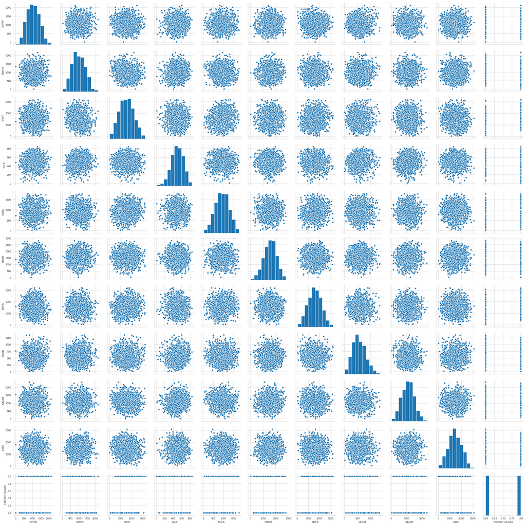

```python
sns.set_style("whitegrid")
sns.pairplot(data)
```

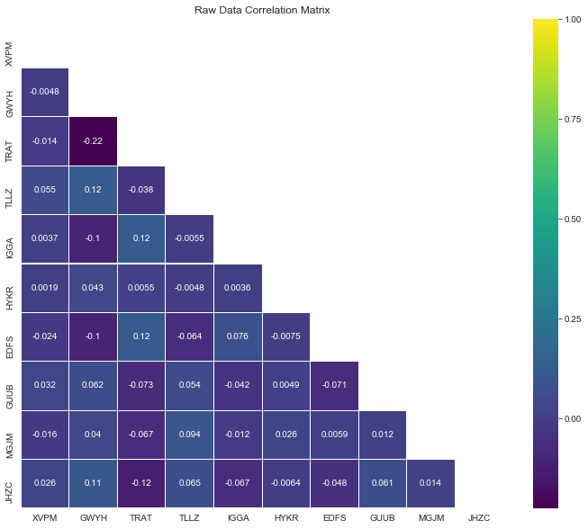

```python
t_data = data.drop(["TARGET CLASS"], axis = 1)

mask = np.zeros_like(t_data.corr())
mask[np.triu_indices_from(mask)] = True

plt.figure(figsize = (12,10))

p1 = sns.heatmap(t_data.corr(), cmap = "viridis",
            annot = True, mask = mask, linewidths = 0.01)

p1.set_title("Raw Data Correlation Matrix")
```

Voila - gotta love artificial data!

# Standardize the Variables

Now it's time to standardize the features of this data set; this involves scaling each feature to its respective unit variance.

```python
from sklearn.preprocessing import StandardScaler

scaler = StandardScaler()

# Computes mean / SD for transformation
scaler.fit(data.drop(["TARGET CLASS"], axis = 1))
```

```
StandardScaler(copy=True, with_mean=True, with_std=True)
```

```python
# Apply fitted scale to data
scaled_data = scaler.transform(data.drop(["TARGET CLASS"], axis = 1))
```

```python
# Push transformed data to Pandas DF object
sc_data = pd.DataFrame(scaled_data, columns = data.columns[:-1])

sc_data.head()
```

|  | XVPM | GWYH | TRAT | TLLZ | IGGA | HYKR | EDFS | GUUB | MGJM | JHZC |
| --- | --- | --- | --- | --- | --- | --- | --- | --- | --- | --- |
| 0 | 1.568522 | -0.443435 | 1.619808 | -0.958255 | -1.128481 | 0.138336 | 0.980493 | -0.932794 | 1.008313 | -1.069627 |
| 1 | -0.112376 | -1.056574 | 1.741918 | -1.504220 | 0.640009 | 1.081552 | -1.182663 | -0.461864 | 0.258321 | -1.041546 |
| 2 | 0.660647 | -0.436981 | 0.775793 | 0.213394 | -0.053171 | 2.030872 | -1.240707 | 1.149298 | 2.184784 | 0.342811 |
| 3 | 0.011533 | 0.191324 | -1.433473 | -0.100053 | -1.507223 | -1.753632 | -1.183561 | -0.888557 | 0.162310 | -0.002793 |
| 4 | -0.099059 | 0.820815 | -0.904346 | 1.609015 | -0.282065 | -0.365099 | -1.095644 | 0.391419 | -1.365603 | 0.787762 |

Success! We observe a dataframe object with data that has been standardized and scaled.

# Train Test Split

Next, we'll need to stratify the data set into training and test components. We'll use 30% of the data as a test-split.

```python
from sklearn.model_selection import train_test_split
```

```python
X = sc_data
y = data["TARGET CLASS"]

X_train, X_test, y_train, y_test = train_test_split(X, y, test_size = 0.3)
```

# Using KNN

We're finally ready to build our KNN model. We'll start with a **n_neighbors** value of 1, but that's just to get us going. We'll eventually optimize the model to reduce the implicit bias in our model.

```python
from sklearn.neighbors import KNeighborsClassifier

knn = KNeighborsClassifier(n_neighbors = 1)

# Fit model to training data
knn.fit(X_train, y_train)
```

```
KNeighborsClassifier(algorithm='auto', leaf_size=30, metric='minkowski',
           metric_params=None, n_jobs=None, n_neighbors=1, p=2,
           weights='uniform')
```

```python
# Use fit to predict test values for TARGET CLASS
preds = knn.predict(X_test)
```

# Predictions and Evaluations

Let's evaluate our KNN model!

```python
from sklearn.metrics import classification_report

print(classification_report(y_test, preds))
```

```
              precision    recall  f1-score   support

           0       0.74      0.74      0.74       147
           1       0.75      0.75      0.75       153

   micro avg       0.74      0.74      0.74       300
   macro avg       0.74      0.74      0.74       300
weighted avg       0.74      0.74      0.74       300
```

# Choosing a K Value

Using the *elbow method* we'll:

- Loop through a range of possible **n_neighbors** values (in this case 1-100)
- Calculate the average error rate at each value
- Select the optimized value.

```python
# We'll be adding error rates to this empty list
errors = []

# Loop through n_neighbors 1-100 and append average error rate to errors
for k in range(1, 100):

    knn = KNeighborsClassifier(n_neighbors = k)
    knn.fit(X_train, y_train)
    predictions = knn.predict(X_test)
    errors.append(np.mean(predictions != y_test))
```

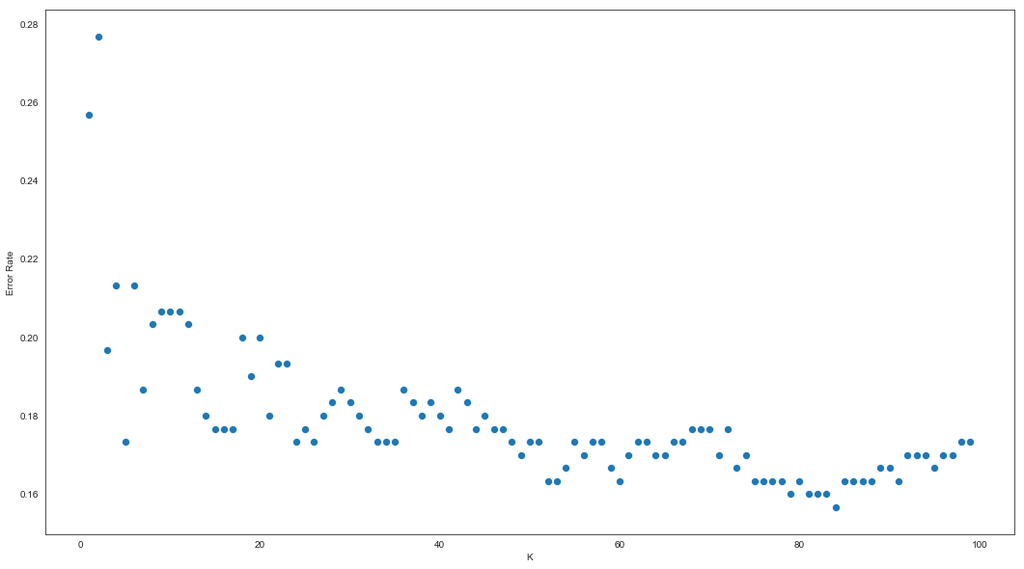

```python
sns.set_style("white")
plt.figure(figsize = (18,10))
p3 = sns.scatterplot(x = range(1,100), y = errors, s = 65)
p3.set_xlabel("K")
p3.set_ylabel("Error Rate")
```

```python
# Optimized N-Neighbors value from errors list
newK = (errors.index(min(errors)) + 1)

newK
```

```
84
```

Using this value, we'll retrain, fit, and predict a KNN model to predict TARGET CLASS on the test data.

## Retraining

```python
uknn = KNeighborsClassifier(n_neighbors = newK)

uknn.fit(X_train, y_train)
```

```
KNeighborsClassifier(algorithm='auto', leaf_size=30, metric='minkowski',
           metric_params=None, n_jobs=None, n_neighbors=84, p=2,
           weights='uniform')
```

```python
upreds = uknn.predict(X_test)
```

```python
print(classification_report(y_test, upreds))
```

```
              precision    recall  f1-score   support

           0       0.90      0.77      0.83       147
           1       0.80      0.92      0.86       153

   micro avg       0.84      0.84      0.84       300
   macro avg       0.85      0.84      0.84       300
weighted avg       0.85      0.84      0.84       300
```

We arrive at our optimized model, which is a marked improvement from our first attempt.